# Laboratorio 2

Luis Pedro Lira 23669, Mario Rocha 23501, Juan Francisco Martínez 23617

2025-02-07

```r
library(psych)
library(FactoMineR)
library(corrplot)
library(fpc)
library(factoextra)
library(PCAmixdata)
library(paran)
library(dplyr)
library(tidyverse)
library(janitor)
library(lubridate)
library(skimr)
library(clustertend)
library(cluster)

datos <- read.csv("movies_2026.csv", stringsAsFactors = FALSE)
```

###Análisis de Componentes Principales (PCA)

###3.1 Selección de Variables y Preprocesamiento

```r
# Selección de variables numéricas
vars_pca <- datos %>%
  select(popularity,
         budget,
         revenue,
         runtime,
         voteCount,
         voteAvg,
         actorsPopularity,
         actorsAmount,
         castWomenAmount,
         castMenAmount,
         genresAmount,
         productionCoAmount,
         productionCountriesAmount,
         releaseYear)

# Reemplazar strings vacíos por NA
vars_pca[vars_pca == ""] <- NA

# Convertir todo a numérico de forma segura
vars_pca <- data.frame(lapply(vars_pca, function(x) as.numeric(as.character(x))))

# Eliminar filas con NA
vars_pca <- na.omit(vars_pca)

# Verificar que todo sea numérico
str(vars_pca)
```

```
## 'data.frame':    1075 obs. of  14 variables:
##  $ popularity               : num  0.0404 0.1112 0.0357 0.1594 0.0143 ...
##  $ budget                   : num  0 0 300 0 0 0 0 7000 0 0 ...
##  $ revenue                  : num  0 0 0 0 0 0 0 0 0 0 ...
##  $ runtime                  : num  45 0 0 6 86 25 88 4 2 10 ...
##  $ voteCount                : num  0 0 0 0 0 0 1 1 0 0 ...
##  $ voteAvg                  : num  0 0 0 0 0 0 10 10 0 0 ...
##  $ actorsPopularity         : num  0.0071 0.0429 0.0214 0.0071 0.6369 ...
##  $ actorsAmount             : num  1 1 1 1 1 1 1 1 1 1 ...
##  $ castWomenAmount          : num  0 0 0 0 0 0 0 0 0 0 ...
##  $ castMenAmount            : num  0 0 0 0 1 1 1 1 1 1 ...
##  $ genresAmount             : num  0 3 1 1 1 0 1 2 1 2 ...
##  $ productionCoAmount       : num  1 0 0 0 1 0 0 1 1 0 ...
##  $ productionCountriesAmount: num  1 1 1 1 1 1 0 0 0 1 ...
##  $ releaseYear              : num  2026 2026 2026 2026 2026 ...
##  - attr(*, "na.action")= 'omit' Named int [1:18808] 1 2 3 4 5 6 7 8 9 10 ...
##   ..- attr(*, "names")= chr [1:18808] "1" "2" "3" "4" ...
```

```r
# Escalar
vars_scaled <- scale(vars_pca)
```

###3.2 Matriz de Correlación

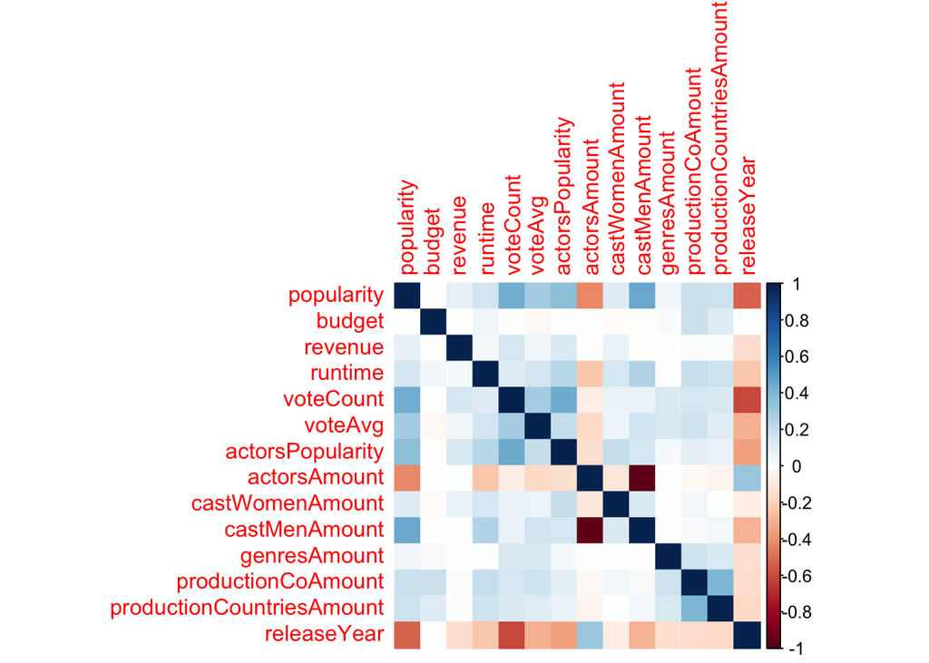

```r
cor_matrix <- cor(vars_scaled)
corrplot(cor_matrix, method = "color")
```

También se observa relación entre voteCount, popularity y actorsPopularity, lo que sugiere que películas con mayor visibilidad tienden a recibir más votos.

Estas correlaciones evidencian redundancia entre variables, lo que justifica la aplicación del Análisis de Componentes Principales para reducir la dimensionalidad del conjunto de datos.

###3.3 Medida de Adecuación Muestral (Índice KMO)

```r
KMO(vars_scaled)
```

```
## Kaiser-Meyer-Olkin factor adequacy
## Call: KMO(r = vars_scaled)
## Overall MSA =  0.69
## MSA for each item =
##                popularity                    budget                   revenue
##                      0.83                      0.63                      0.84
##                   runtime                 voteCount                   voteAvg
##                      0.73                      0.74                      0.90
##          actorsPopularity              actorsAmount           castWomenAmount
##                      0.80                      0.57                      0.76
##             castMenAmount              genresAmount        productionCoAmount
##                      0.57                      0.72                      0.67
## productionCountriesAmount               releaseYear
##                      0.69                      0.74
```

El índice KMO global obtenido fue de 0.69, lo cual indica una adecuación muestral aceptable para aplicar el Análisis de Componentes Principales.

Según la clasificación de Kaiser: • 0.90 → Excelente • 0.80 → Muy bueno • 0.70 → Bueno • 0.60 → Aceptable • <0.50 → Inadecuado

En este caso, el valor se encuentra cercano a 0.70, lo que sugiere que las correlaciones parciales entre variables no son excesivamente altas y que el análisis factorial es apropiado, aunque no óptimo.

###3.4 Prueba de Esfericidad de Bartlett

```r
cortest.bartlett(cor_matrix, n = nrow(vars_scaled))
```

```
## $chisq
## [1] 5416.441
##
## $p.value
## [1] 0
##
## $df
## [1] 91
```

La prueba de esfericidad de Bartlett resultó altamente significativa (χ² = 5416.44, p < 0.001), lo que permite rechazar la hipótesis nula de que la matriz de correlación es una matriz identidad.

Esto confirma que existe correlación suficiente entre las variables y que el Análisis de Componentes Principales es apropiado para este conjunto de datos.

###3.5 Aplicación del Análisis de Componentes Principales

```r
pca_model <- prcomp(vars_scaled, center = TRUE, scale. = TRUE)

summary(pca_model)
```

```
## Importance of components:
##                           PC1    PC2    PC3     PC4     PC5     PC6     PC7
## Standard deviation     1.8434 1.3269 1.1929 1.05639 0.98343 0.95596 0.93911
## Proportion of Variance 0.2427 0.1258 0.1017 0.07971 0.06908 0.06528 0.06299
## Cumulative Proportion  0.2427 0.3685 0.4701 0.54983 0.61891 0.68419 0.74718
##                            PC8     PC9    PC10    PC11    PC12    PC13    PC14
## Standard deviation     0.89506 0.87855 0.76897 0.75538 0.66624 0.57717 0.16590
## Proportion of Variance 0.05722 0.05513 0.04224 0.04076 0.03171 0.02379 0.00197
## Cumulative Proportion  0.80441 0.85954 0.90178 0.94253 0.97424 0.99803 1.00000
```

##3.6 Determinación del Número de Componentes (Scree Plot y Varianza Explicada)

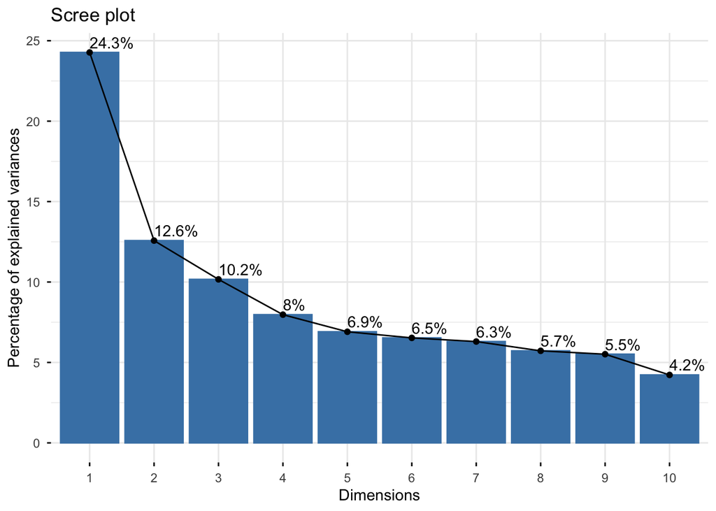

```r
fviz_eig(pca_model, addlabels = TRUE)
```

```r
eigenvalues <- pca_model$sdev^2
eigenvalues
```

```
##  [1] 3.39812748 1.76053146 1.42304682 1.11596354 0.96713359 0.91386270
##  [7] 0.88192312 0.80112853 0.77184452 0.59131760 0.57059723 0.44387318
## [13] 0.33312887 0.02752134
```

El primer componente principal explica el 24.3% de la variabilidad total, seguido por el segundo con 12.6% y el tercero con 10.2%.

Se decidió conservar los primeros 7 componentes, ya que explican aproximadamente el 74.7% de la variabilidad total, lo cual representa una reducción considerable de dimensionalidad manteniendo una proporción adecuada de información.

###3.7 Interpretación de los Componentes Principales

```r
loadings <- pca_model$rotation
round(loadings, 3)
```

```
##                              PC1    PC2    PC3    PC4    PC5    PC6    PC7
## popularity                 0.410  0.031  0.076 -0.139  0.108  0.076  0.001
## budget                     0.021 -0.128 -0.384  0.184  0.542  0.052  0.671
## revenue                    0.090 -0.130  0.246  0.298  0.416 -0.747 -0.272
## runtime                    0.240  0.012 -0.207  0.410 -0.152  0.200 -0.231
## voteCount                  0.333 -0.314  0.318 -0.130  0.118  0.158  0.086
## voteAvg                    0.264 -0.148  0.049 -0.207 -0.221 -0.014 -0.029
## actorsPopularity           0.303 -0.171  0.282  0.272 -0.035  0.234  0.126
## actorsAmount              -0.351 -0.521  0.159  0.083 -0.045  0.124 -0.021
## castWomenAmount            0.131  0.031  0.088  0.600 -0.497 -0.180  0.315
## castMenAmount              0.353  0.525 -0.162 -0.060  0.031 -0.119  0.022
## genresAmount               0.090 -0.249 -0.150 -0.397 -0.404 -0.498  0.362
## productionCoAmount         0.174 -0.329 -0.482  0.059 -0.055 -0.021 -0.147
## productionCountriesAmount  0.165 -0.285 -0.461  0.023  0.016 -0.008 -0.380
## releaseYear               -0.404  0.127 -0.186  0.155 -0.137 -0.065 -0.013
##                              PC8    PC9   PC10   PC11   PC12   PC13   PC14
## popularity                 0.260 -0.130 -0.131  0.078  0.817 -0.101  0.049
## budget                    -0.160 -0.084  0.062 -0.131  0.044 -0.005  0.000
## revenue                   -0.125 -0.020 -0.062  0.015  0.024 -0.027  0.002
## runtime                   -0.557  0.436  0.201  0.051  0.225 -0.143  0.025
## voteCount                  0.110  0.076  0.237  0.086 -0.313 -0.669  0.008
## voteAvg                   -0.566 -0.660 -0.032 -0.233 -0.040  0.028 -0.004
## actorsPopularity           0.021  0.202 -0.703 -0.193 -0.184  0.216  0.003
## actorsAmount              -0.028 -0.014  0.046  0.007  0.249  0.034 -0.699
## castWomenAmount            0.310 -0.256  0.272 -0.012  0.014 -0.004  0.007
## castMenAmount              0.027  0.018 -0.083 -0.012 -0.174 -0.108 -0.710
## genresAmount              -0.083  0.425 -0.090 -0.056  0.092 -0.021  0.006
## productionCoAmount         0.105 -0.194 -0.227  0.685 -0.170  0.050 -0.007
## productionCountriesAmount  0.362  0.009  0.091 -0.624 -0.067 -0.012 -0.004
## releaseYear               -0.044 -0.139 -0.482 -0.112  0.104 -0.677  0.057
```

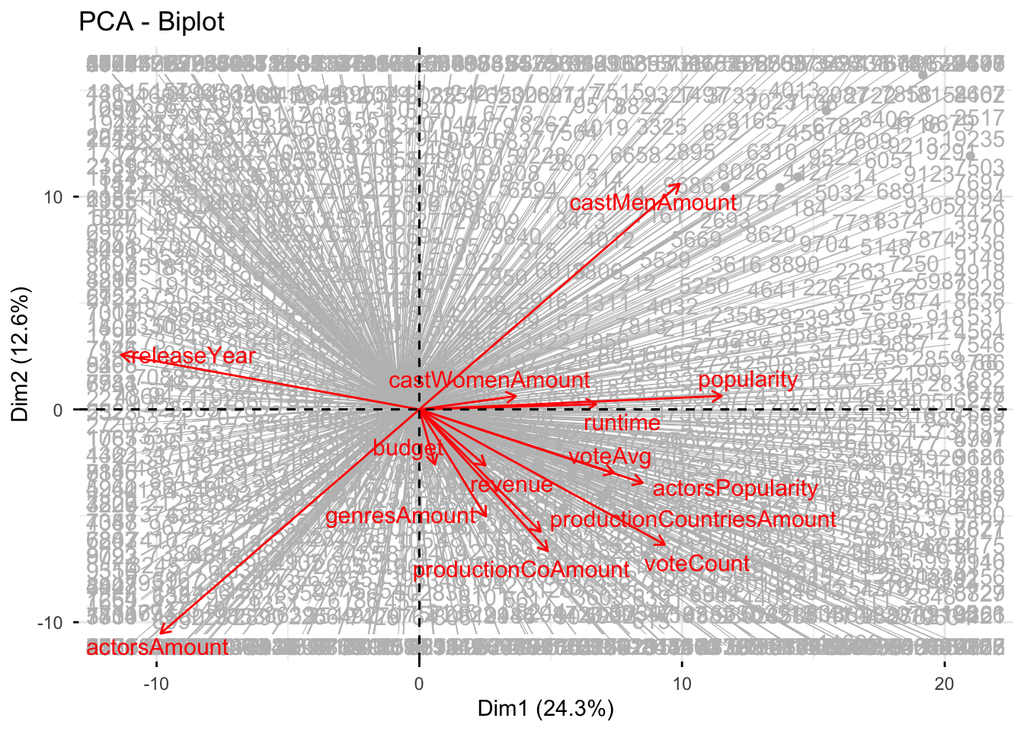

```r
fviz_pca_biplot(pca_model,
                repel = TRUE,
                col.var = "red",
                col.ind = "gray")
```

El primer componente parece representar una dimensión de impacto y visibilidad comercial, ya que agrupa variables relacionadas con popularidad, número de votos y popularidad del elenco.

La carga negativa en releaseYear sugiere que películas más antiguas tienden a tener mayor acumulación de popularidad y votos, lo cual puede deberse a mayor tiempo en el mercado.

###3.8 Conclusiones del PCA

El Análisis de Componentes Principales permitió reducir la dimensionalidad del conjunto de datos original compuesto por 14 variables numéricas, sintetizando la información en un menor número de componentes sin perder una proporción significativa de variabilidad.